# Risk Factor Analysis

## Outcome Variable

**Outcome Variable:** ever_stunted

## Predictor Variables

**Intervention Variable:** fhtcm

**Adjustment Set:**

- arm
- W_mage
- W_fage
- meducyrs
- feducyrs
- W_mhtcm
- W_mwtkg
- W_mbmi
- single
- delta_W_mage
- delta_W_fage
- delta_meducyrs
- delta_feducyrs
- delta_W_mhtcm
- delta_W_mwtkg
- delta_W_mbmi
- delta_single

## Stratifying Variables

The analysis was stratified on these variable(s):

- agecat
- studyid
- country

## Data Summary

| agecat | studyid | country | fhtcm | ever_stunted | n_cell | n |
| --- | --- | --- | --- | --- | --- | --- |
| 0-24 months | COHORTS | GUATEMALA | >=167 cm | 0 | 16 | 496 |
| 0-24 months | COHORTS | GUATEMALA | >=167 cm | 1 | 48 | 496 |
| 0-24 months | COHORTS | GUATEMALA | <162 cm | 0 | 24 | 496 |
| 0-24 months | COHORTS | GUATEMALA | <162 cm | 1 | 269 | 496 |
| 0-24 months | COHORTS | GUATEMALA | [162-167) cm | 0 | 24 | 496 |
| 0-24 months | COHORTS | GUATEMALA | [162-167) cm | 1 | 115 | 496 |
| 0-24 months | Keneba | GAMBIA | >=167 cm | 0 | 598 | 1929 |
| 0-24 months | Keneba | GAMBIA | >=167 cm | 1 | 647 | 1929 |
| 0-24 months | Keneba | GAMBIA | <162 cm | 0 | 52 | 1929 |
| 0-24 months | Keneba | GAMBIA | <162 cm | 1 | 80 | 1929 |
| 0-24 months | Keneba | GAMBIA | [162-167) cm | 0 | 207 | 1929 |
| 0-24 months | Keneba | GAMBIA | [162-167) cm | 1 | 345 | 1929 |
| 0-24 months | PROBIT | BELARUS | >=167 cm | 0 | 10314 | 12537 |
| 0-24 months | PROBIT | BELARUS | >=167 cm | 1 | 1430 | 12537 |
| 0-24 months | PROBIT | BELARUS | <162 cm | 0 | 122 | 12537 |
| 0-24 months | PROBIT | BELARUS | <162 cm | 1 | 46 | 12537 |
| 0-24 months | PROBIT | BELARUS | [162-167) cm | 0 | 495 | 12537 |
| 0-24 months | PROBIT | BELARUS | [162-167) cm | 1 | 130 | 12537 |
| 0-24 months | SAS-CompFeed | INDIA | >=167 cm | 0 | 137 | 907 |
| 0-24 months | SAS-CompFeed | INDIA | >=167 cm | 1 | 273 | 907 |
| 0-24 months | SAS-CompFeed | INDIA | <162 cm | 0 | 50 | 907 |
| 0-24 months | SAS-CompFeed | INDIA | <162 cm | 1 | 180 | 907 |
| 0-24 months | SAS-CompFeed | INDIA | [162-167) cm | 0 | 69 | 907 |
| 0-24 months | SAS-CompFeed | INDIA | [162-167) cm | 1 | 198 | 907 |
| 0-24 months | SAS-FoodSuppl | INDIA | >=167 cm | 0 | 23 | 399 |
| 0-24 months | SAS-FoodSuppl | INDIA | >=167 cm | 1 | 83 | 399 |
| 0-24 months | SAS-FoodSuppl | INDIA | <162 cm | 0 | 15 | 399 |
| 0-24 months | SAS-FoodSuppl | INDIA | <162 cm | 1 | 148 | 399 |
| 0-24 months | SAS-FoodSuppl | INDIA | [162-167) cm | 0 | 23 | 399 |
| 0-24 months | SAS-FoodSuppl | INDIA | [162-167) cm | 1 | 107 | 399 |

[output cut: 60 more lines]

The following strata were considered:

- agecat: 0-24 months, studyid: COHORTS, country: GUATEMALA
- agecat: 0-24 months, studyid: Keneba, country: GAMBIA
- agecat: 0-24 months, studyid: PROBIT, country: BELARUS
- agecat: 0-24 months, studyid: SAS-CompFeed, country: INDIA
- agecat: 0-24 months, studyid: SAS-FoodSuppl, country: INDIA
- agecat: 0-6 months, studyid: COHORTS, country: GUATEMALA
- agecat: 0-6 months, studyid: Keneba, country: GAMBIA
- agecat: 0-6 months, studyid: PROBIT, country: BELARUS
- agecat: 0-6 months, studyid: SAS-CompFeed, country: INDIA
- agecat: 0-6 months, studyid: SAS-FoodSuppl, country: INDIA
- agecat: 6-24 months, studyid: COHORTS, country: GUATEMALA
- agecat: 6-24 months, studyid: Keneba, country: GAMBIA
- agecat: 6-24 months, studyid: PROBIT, country: BELARUS
- agecat: 6-24 months, studyid: SAS-CompFeed, country: INDIA
- agecat: 6-24 months, studyid: SAS-FoodSuppl, country: INDIA

## Methods Detail

We're interested in the causal parameters $E[Y_a]$ for all values of $a \in \mathcal{A}$. These parameters represent the mean outcome if, possibly contrary to fact, we intervened to set all units to have $A=a$. Under the randomization and positivity assumptions, these are identified by the statistical parameters $\psi_a=E_W[E_{Y|A,W}(Y|A=a,W)]$. In addition, we're interested in the mean of $Y$, $E[Y]$ under no intervention (the observed mean). We will estimate these parameters by using SuperLearner to fit the relevant likelihood factors -- $E_{Y|A,W}(Y|A=a,W)$ and $p(A=a|W)$, and then updating our likelihood fit using a joint TMLE.

For unadjusted analyses ($W=\{\}$), initial likelihoods were estimated using Lrnr_glm to estimate the simple $E(Y|A)$ and Lrnr_mean to estimate $p(A)$. For adjusted analyses, a small library containing Lrnr_glmnet, Lrnr_xgboost, and Lrnr_mean was used.

Having estimated these parameters, we will then use the delta method to estimate relative risks and attributable risks relative to a prespecified baseline level of $A$.

# Results Detail

## Results Plots

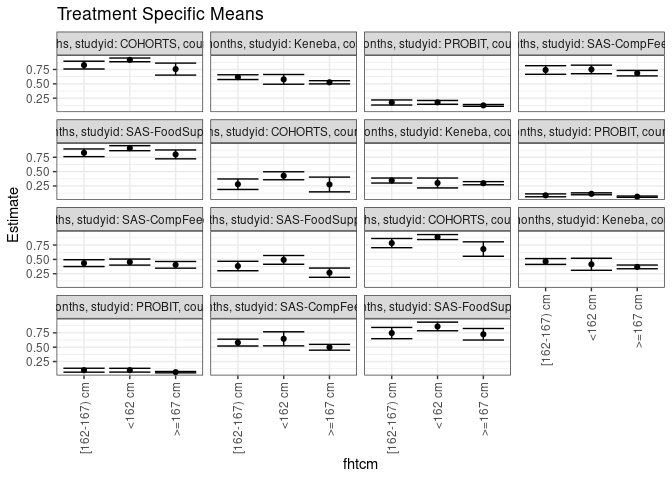

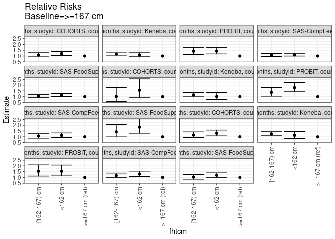

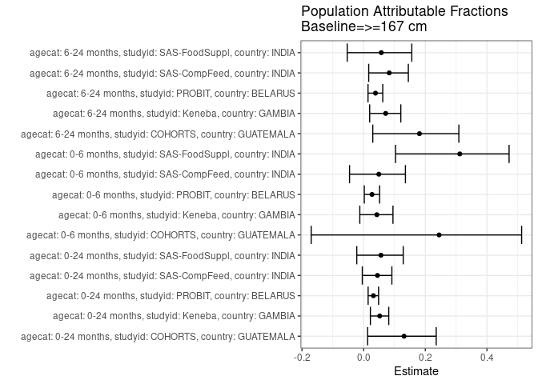

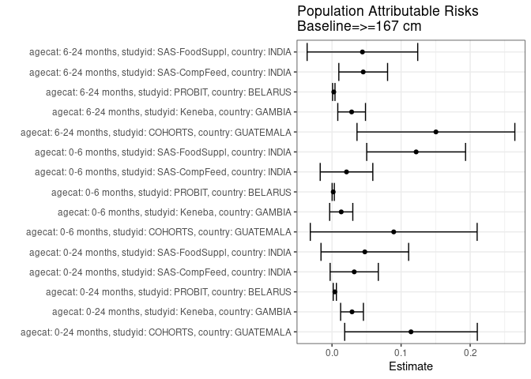

## Results Table

### Parameter: TSM

| agecat | studyid | country | intervention_level | baseline_level | estimate | ci_lower | ci_upper |
| --- | --- | --- | --- | --- | --- | --- | --- |
| 0-24 months | COHORTS | GUATEMALA | >=167 cm | NA | 0.7566212 | 0.6520420 | 0.8612004 |
| 0-24 months | COHORTS | GUATEMALA | <162 cm | NA | 0.9170720 | 0.8847322 | 0.9494118 |
| 0-24 months | COHORTS | GUATEMALA | [162-167) cm | NA | 0.8261908 | 0.7582995 | 0.8940822 |
| 0-24 months | Keneba | GAMBIA | >=167 cm | NA | 0.5267517 | 0.4987862 | 0.5547171 |
| 0-24 months | Keneba | GAMBIA | <162 cm | NA | 0.5772932 | 0.4925389 | 0.6620474 |
| 0-24 months | Keneba | GAMBIA | [162-167) cm | NA | 0.6163008 | 0.5747574 | 0.6578441 |
| 0-24 months | PROBIT | BELARUS | >=167 cm | NA | 0.1240485 | 0.1086700 | 0.1394271 |
| 0-24 months | PROBIT | BELARUS | <162 cm | NA | 0.1769690 | 0.1437928 | 0.2101451 |
| 0-24 months | PROBIT | BELARUS | [162-167) cm | NA | 0.1746938 | 0.1303277 | 0.2190599 |
| 0-24 months | SAS-CompFeed | INDIA | >=167 cm | NA | 0.6855886 | 0.6382807 | 0.7328966 |
| 0-24 months | SAS-CompFeed | INDIA | <162 cm | NA | 0.7505702 | 0.6757926 | 0.8253478 |
| 0-24 months | SAS-CompFeed | INDIA | [162-167) cm | NA | 0.7406719 | 0.6659023 | 0.8154414 |
| 0-24 months | SAS-FoodSuppl | INDIA | >=167 cm | NA | 0.7996122 | 0.7223775 | 0.8768468 |
| 0-24 months | SAS-FoodSuppl | INDIA | <162 cm | NA | 0.9081807 | 0.8644819 | 0.9518796 |
| 0-24 months | SAS-FoodSuppl | INDIA | [162-167) cm | NA | 0.8275592 | 0.7609202 | 0.8941983 |
| 0-6 months | COHORTS | GUATEMALA | >=167 cm | NA | 0.2756595 | 0.1470901 | 0.4042289 |
| 0-6 months | COHORTS | GUATEMALA | <162 cm | NA | 0.4277628 | 0.3580152 | 0.4975105 |
| 0-6 months | COHORTS | GUATEMALA | [162-167) cm | NA | 0.2805047 | 0.1889041 | 0.3721053 |
| 0-6 months | Keneba | GAMBIA | >=167 cm | NA | 0.2983021 | 0.2709919 | 0.3256123 |
| 0-6 months | Keneba | GAMBIA | <162 cm | NA | 0.3018417 | 0.2157589 | 0.3879245 |
| 0-6 months | Keneba | GAMBIA | [162-167) cm | NA | 0.3449050 | 0.3013054 | 0.3885045 |
| 0-6 months | PROBIT | BELARUS | >=167 cm | NA | 0.0634680 | 0.0524536 | 0.0744824 |
| 0-6 months | PROBIT | BELARUS | <162 cm | NA | 0.1132110 | 0.0965061 | 0.1299158 |
| 0-6 months | PROBIT | BELARUS | [162-167) cm | NA | 0.0868379 | 0.0618192 | 0.1118565 |
| 0-6 months | SAS-CompFeed | INDIA | >=167 cm | NA | 0.4055241 | 0.3473816 | 0.4636666 |
| 0-6 months | SAS-CompFeed | INDIA | <162 cm | NA | 0.4533901 | 0.4010173 | 0.5057630 |
| 0-6 months | SAS-CompFeed | INDIA | [162-167) cm | NA | 0.4349737 | 0.3758340 | 0.4941134 |
| 0-6 months | SAS-FoodSuppl | INDIA | >=167 cm | NA | 0.2686484 | 0.1880799 | 0.3492169 |
| 0-6 months | SAS-FoodSuppl | INDIA | <162 cm | NA | 0.4917046 | 0.4153641 | 0.5680451 |
| 0-6 months | SAS-FoodSuppl | INDIA | [162-167) cm | NA | 0.3845542 | 0.3025257 | 0.4665826 |
| 6-24 months | COHORTS | GUATEMALA | >=167 cm | NA | 0.6802230 | 0.5546807 | 0.8057653 |
| 6-24 months | COHORTS | GUATEMALA | <162 cm | NA | 0.8891284 | 0.8452376 | 0.9330192 |
| 6-24 months | COHORTS | GUATEMALA | [162-167) cm | NA | 0.7841514 | 0.7037973 | 0.8645054 |
| 6-24 months | Keneba | GAMBIA | >=167 cm | NA | 0.3693471 | 0.3368423 | 0.4018520 |
| 6-24 months | Keneba | GAMBIA | <162 cm | NA | 0.4148412 | 0.3098062 | 0.5198762 |
| 6-24 months | Keneba | GAMBIA | [162-167) cm | NA | 0.4637273 | 0.4130895 | 0.5143652 |
| 6-24 months | PROBIT | BELARUS | >=167 cm | NA | 0.0646954 | 0.0530254 | 0.0763654 |
| 6-24 months | PROBIT | BELARUS | <162 cm | NA | 0.0993141 | 0.0663756 | 0.1322525 |
| 6-24 months | PROBIT | BELARUS | [162-167) cm | NA | 0.0989282 | 0.0646978 | 0.1331585 |
| 6-24 months | SAS-CompFeed | INDIA | >=167 cm | NA | 0.4989882 | 0.4484602 | 0.5495162 |
| 6-24 months | SAS-CompFeed | INDIA | <162 cm | NA | 0.6460631 | 0.5238846 | 0.7682415 |
| 6-24 months | SAS-CompFeed | INDIA | [162-167) cm | NA | 0.5800966 | 0.5207037 | 0.6394895 |
| 6-24 months | SAS-FoodSuppl | INDIA | >=167 cm | NA | 0.7248748 | 0.6243507 | 0.8253989 |
| 6-24 months | SAS-FoodSuppl | INDIA | <162 cm | NA | 0.8611705 | 0.7859227 | 0.9364184 |
| 6-24 months | SAS-FoodSuppl | INDIA | [162-167) cm | NA | 0.7460705 | 0.6477887 | 0.8443523 |

### Parameter: E(Y)

| agecat | studyid | country | intervention_level | baseline_level | estimate | ci_lower | ci_upper |
| --- | --- | --- | --- | --- | --- | --- | --- |
| 0-24 months | COHORTS | GUATEMALA | NA | NA | 0.8709677 | 0.8414356 | 0.9004999 |
| 0-24 months | Keneba | GAMBIA | NA | NA | 0.5557284 | 0.5335489 | 0.5779078 |
| 0-24 months | PROBIT | BELARUS | NA | NA | 0.1281008 | 0.1120747 | 0.1441270 |
| 0-24 months | SAS-CompFeed | INDIA | NA | NA | 0.7177508 | 0.6751525 | 0.7603491 |
| 0-24 months | SAS-FoodSuppl | INDIA | NA | NA | 0.8471178 | 0.8117623 | 0.8824733 |
| 0-6 months | COHORTS | GUATEMALA | NA | NA | 0.3649852 | 0.3135088 | 0.4164615 |
| 0-6 months | Keneba | GAMBIA | NA | NA | 0.3116657 | 0.2897893 | 0.3335421 |
| 0-6 months | PROBIT | BELARUS | NA | NA | 0.0652469 | 0.0543989 | 0.0760949 |
| 0-6 months | SAS-CompFeed | INDIA | NA | NA | 0.4265193 | 0.3923837 | 0.4606550 |
| 0-6 months | SAS-FoodSuppl | INDIA | NA | NA | 0.3904282 | 0.3423793 | 0.4384771 |
| 6-24 months | COHORTS | GUATEMALA | NA | NA | 0.8306452 | 0.7924799 | 0.8688104 |
| 6-24 months | Keneba | GAMBIA | NA | NA | 0.3977695 | 0.3716030 | 0.4239360 |
| 6-24 months | PROBIT | BELARUS | NA | NA | 0.0672814 | 0.0549972 | 0.0795656 |
| 6-24 months | SAS-CompFeed | INDIA | NA | NA | 0.5441478 | 0.5023342 | 0.5859615 |
| 6-24 months | SAS-FoodSuppl | INDIA | NA | NA | 0.7689076 | 0.7152410 | 0.8225741 |

### Parameter: RR

| agecat | studyid | country | intervention_level | baseline_level | estimate | ci_lower | ci_upper |
| --- | --- | --- | --- | --- | --- | --- | --- |
| 0-24 months | COHORTS | GUATEMALA | >=167 cm | >=167 cm | 1.000000 | 1.0000000 | 1.000000 |
| 0-24 months | COHORTS | GUATEMALA | <162 cm | >=167 cm | 1.212062 | 1.0511471 | 1.397611 |
| 0-24 months | COHORTS | GUATEMALA | [162-167) cm | >=167 cm | 1.091948 | 0.9299958 | 1.282102 |
| 0-24 months | Keneba | GAMBIA | >=167 cm | >=167 cm | 1.000000 | 1.0000000 | 1.000000 |
| 0-24 months | Keneba | GAMBIA | <162 cm | >=167 cm | 1.095949 | 0.9379937 | 1.280504 |
| 0-24 months | Keneba | GAMBIA | [162-167) cm | >=167 cm | 1.170003 | 1.0749567 | 1.273452 |
| 0-24 months | PROBIT | BELARUS | >=167 cm | >=167 cm | 1.000000 | 1.0000000 | 1.000000 |
| 0-24 months | PROBIT | BELARUS | <162 cm | >=167 cm | 1.426611 | 1.1801963 | 1.724474 |
| 0-24 months | PROBIT | BELARUS | [162-167) cm | >=167 cm | 1.408270 | 1.1331980 | 1.750113 |
| 0-24 months | SAS-CompFeed | INDIA | >=167 cm | >=167 cm | 1.000000 | 1.0000000 | 1.000000 |
| 0-24 months | SAS-CompFeed | INDIA | <162 cm | >=167 cm | 1.094782 | 0.9982849 | 1.200607 |
| 0-24 months | SAS-CompFeed | INDIA | [162-167) cm | >=167 cm | 1.080344 | 0.9553606 | 1.221679 |
| 0-24 months | SAS-FoodSuppl | INDIA | >=167 cm | >=167 cm | 1.000000 | 1.0000000 | 1.000000 |
| 0-24 months | SAS-FoodSuppl | INDIA | <162 cm | >=167 cm | 1.135776 | 1.0199956 | 1.264700 |
| 0-24 months | SAS-FoodSuppl | INDIA | [162-167) cm | >=167 cm | 1.034951 | 0.9129768 | 1.173221 |
| 0-6 months | COHORTS | GUATEMALA | >=167 cm | >=167 cm | 1.000000 | 1.0000000 | 1.000000 |
| 0-6 months | COHORTS | GUATEMALA | <162 cm | >=167 cm | 1.551780 | 0.9459691 | 2.545560 |
| 0-6 months | COHORTS | GUATEMALA | [162-167) cm | >=167 cm | 1.017577 | 0.5762919 | 1.796767 |
| 0-6 months | Keneba | GAMBIA | >=167 cm | >=167 cm | 1.000000 | 1.0000000 | 1.000000 |
| 0-6 months | Keneba | GAMBIA | <162 cm | >=167 cm | 1.011866 | 0.7501597 | 1.364872 |
| 0-6 months | Keneba | GAMBIA | [162-167) cm | >=167 cm | 1.156227 | 0.9898704 | 1.350541 |
| 0-6 months | PROBIT | BELARUS | >=167 cm | >=167 cm | 1.000000 | 1.0000000 | 1.000000 |
| 0-6 months | PROBIT | BELARUS | <162 cm | >=167 cm | 1.783749 | 1.4255784 | 2.231908 |
| 0-6 months | PROBIT | BELARUS | [162-167) cm | >=167 cm | 1.368215 | 1.0436059 | 1.793792 |
| 0-6 months | SAS-CompFeed | INDIA | >=167 cm | >=167 cm | 1.000000 | 1.0000000 | 1.000000 |
| 0-6 months | SAS-CompFeed | INDIA | <162 cm | >=167 cm | 1.118035 | 0.9361099 | 1.335316 |
| 0-6 months | SAS-CompFeed | INDIA | [162-167) cm | >=167 cm | 1.072621 | 0.8831436 | 1.302750 |
| 0-6 months | SAS-FoodSuppl | INDIA | >=167 cm | >=167 cm | 1.000000 | 1.0000000 | 1.000000 |
| 0-6 months | SAS-FoodSuppl | INDIA | <162 cm | >=167 cm | 1.830290 | 1.3112669 | 2.554752 |
| 0-6 months | SAS-FoodSuppl | INDIA | [162-167) cm | >=167 cm | 1.431440 | 0.9944906 | 2.060372 |
| 6-24 months | COHORTS | GUATEMALA | >=167 cm | >=167 cm | 1.000000 | 1.0000000 | 1.000000 |
| 6-24 months | COHORTS | GUATEMALA | <162 cm | >=167 cm | 1.307113 | 1.0800896 | 1.581855 |
| 6-24 months | COHORTS | GUATEMALA | [162-167) cm | >=167 cm | 1.152786 | 0.9338519 | 1.423047 |
| 6-24 months | Keneba | GAMBIA | >=167 cm | >=167 cm | 1.000000 | 1.0000000 | 1.000000 |
| 6-24 months | Keneba | GAMBIA | <162 cm | >=167 cm | 1.123174 | 0.8597395 | 1.467329 |
| 6-24 months | Keneba | GAMBIA | [162-167) cm | >=167 cm | 1.255532 | 1.0931233 | 1.442071 |
| 6-24 months | PROBIT | BELARUS | >=167 cm | >=167 cm | 1.000000 | 1.0000000 | 1.000000 |
| 6-24 months | PROBIT | BELARUS | <162 cm | >=167 cm | 1.535103 | 1.1358355 | 2.074720 |
| 6-24 months | PROBIT | BELARUS | [162-167) cm | >=167 cm | 1.529138 | 1.1205286 | 2.086751 |
| 6-24 months | SAS-CompFeed | INDIA | >=167 cm | >=167 cm | 1.000000 | 1.0000000 | 1.000000 |
| 6-24 months | SAS-CompFeed | INDIA | <162 cm | >=167 cm | 1.294746 | 1.0827519 | 1.548247 |
| 6-24 months | SAS-CompFeed | INDIA | [162-167) cm | >=167 cm | 1.162546 | 0.9803834 | 1.378555 |
| 6-24 months | SAS-FoodSuppl | INDIA | >=167 cm | >=167 cm | 1.000000 | 1.0000000 | 1.000000 |
| 6-24 months | SAS-FoodSuppl | INDIA | <162 cm | >=167 cm | 1.188027 | 1.0093728 | 1.398301 |
| 6-24 months | SAS-FoodSuppl | INDIA | [162-167) cm | >=167 cm | 1.029241 | 0.8505948 | 1.245406 |

### Parameter: PAR

| agecat | studyid | country | intervention_level | baseline_level | estimate | ci_lower | ci_upper |
| --- | --- | --- | --- | --- | --- | --- | --- |
| 0-24 months | COHORTS | GUATEMALA | >=167 cm | NA | 0.1143465 | 0.0183718 | 0.2103213 |
| 0-24 months | Keneba | GAMBIA | >=167 cm | NA | 0.0289767 | 0.0125019 | 0.0454515 |
| 0-24 months | PROBIT | BELARUS | >=167 cm | NA | 0.0040523 | 0.0017586 | 0.0063460 |
| 0-24 months | SAS-CompFeed | INDIA | >=167 cm | NA | 0.0321622 | -0.0027182 | 0.0670425 |
| 0-24 months | SAS-FoodSuppl | INDIA | >=167 cm | NA | 0.0475056 | -0.0159183 | 0.1109296 |
| 0-6 months | COHORTS | GUATEMALA | >=167 cm | NA | 0.0893257 | -0.0314300 | 0.2100814 |
| 0-6 months | Keneba | GAMBIA | >=167 cm | NA | 0.0133636 | -0.0033822 | 0.0301093 |
| 0-6 months | PROBIT | BELARUS | >=167 cm | NA | 0.0017789 | 0.0001931 | 0.0033646 |
| 0-6 months | SAS-CompFeed | INDIA | >=167 cm | NA | 0.0209952 | -0.0170810 | 0.0590714 |
| 0-6 months | SAS-FoodSuppl | INDIA | >=167 cm | NA | 0.1217798 | 0.0502484 | 0.1933112 |
| 6-24 months | COHORTS | GUATEMALA | >=167 cm | NA | 0.1504222 | 0.0362025 | 0.2646418 |
| 6-24 months | Keneba | GAMBIA | >=167 cm | NA | 0.0284224 | 0.0083692 | 0.0484755 |
| 6-24 months | PROBIT | BELARUS | >=167 cm | NA | 0.0025860 | 0.0008407 | 0.0043314 |
| 6-24 months | SAS-CompFeed | INDIA | >=167 cm | NA | 0.0451596 | 0.0098738 | 0.0804455 |
| 6-24 months | SAS-FoodSuppl | INDIA | >=167 cm | NA | 0.0440327 | -0.0360064 | 0.1240719 |

### Parameter: PAF

| agecat | studyid | country | intervention_level | baseline_level | estimate | ci_lower | ci_upper |
| --- | --- | --- | --- | --- | --- | --- | --- |
| 0-24 months | COHORTS | GUATEMALA | >=167 cm | NA | 0.1312868 | 0.0129392 | 0.2354446 |
| 0-24 months | Keneba | GAMBIA | >=167 cm | NA | 0.0521418 | 0.0218978 | 0.0814506 |
| 0-24 months | PROBIT | BELARUS | >=167 cm | NA | 0.0316335 | 0.0145457 | 0.0484251 |
| 0-24 months | SAS-CompFeed | INDIA | >=167 cm | NA | 0.0448097 | -0.0043700 | 0.0915812 |
| 0-24 months | SAS-FoodSuppl | INDIA | >=167 cm | NA | 0.0560791 | -0.0222704 | 0.1284238 |
| 0-6 months | COHORTS | GUATEMALA | >=167 cm | NA | 0.2447378 | -0.1702007 | 0.5125444 |
| 0-6 months | Keneba | GAMBIA | >=167 cm | NA | 0.0428779 | -0.0124207 | 0.0951561 |
| 0-6 months | PROBIT | BELARUS | >=167 cm | NA | 0.0272637 | 0.0020752 | 0.0518164 |
| 0-6 months | SAS-CompFeed | INDIA | >=167 cm | NA | 0.0492245 | -0.0457341 | 0.1355603 |
| 0-6 months | SAS-FoodSuppl | INDIA | >=167 cm | NA | 0.3119134 | 0.1035559 | 0.4718430 |
| 6-24 months | COHORTS | GUATEMALA | >=167 cm | NA | 0.1810908 | 0.0296541 | 0.3088936 |
| 6-24 months | Keneba | GAMBIA | >=167 cm | NA | 0.0714544 | 0.0195585 | 0.1206034 |
| 6-24 months | PROBIT | BELARUS | >=167 cm | NA | 0.0384363 | 0.0142328 | 0.0620454 |
| 6-24 months | SAS-CompFeed | INDIA | >=167 cm | NA | 0.0829915 | 0.0164857 | 0.1450001 |
| 6-24 months | SAS-FoodSuppl | INDIA | >=167 cm | NA | 0.0572666 | -0.0533025 | 0.1562289 |